# 2YP Notebook

### METHODS

##### 1. Participants

316 (69% female) English speakers aged 17 to 33 were recruited from the experimental-subject pool at a large public university in the United States (M(age) = 20.5, SD(age) = 2.2). Participants completed three activities: two graph reading tasks followed by a drawing task. In some cases (order = linear-first), participants (n = 154) completed the first graph reading task with a linear model graph, followed by the task with the triangular graph. To control for any effects of graph order on performance, an additional (n= 162) subjects completed the activities with the graphs in reverse order. Each participant was randomly assigned to one of five conditions which determined what additional information (scaffold) they received while solving the first five problems on each graph reading task: no-scaffold (control), ‘what’ text, ‘how’-text, static-image, interactive-image. The runtime of the entire study ranged from 22 to 66 minutes (M = 40, SD = 8.54).

In addition, we ran 6 expert participants through two conditions, composed of research assistants with more than 20 hours of experience analyzing data with the triangular model graph.

##### 2. Group Totals

Participants were randomnly assigned to task order (LMFirst, TMFirst) and Scaffold Condition (none, what-text, how-text, static image, interactive image) conditions

| Condition | Task Order TMFirst | Task Order LMFirst | All |
| --- | --- | --- | --- |
| 0 | 32 | 29 | 61 |
| 1 | 28 | 31 | 59 |
| 2 | 36 | 30 | 66 |
| 3 | 32 | 30 | 62 |
| 4 | 34 | 34 | 68 |
| All | 162 | 154 | 316 |

### EXPLORATION

##### Relationship between graph time and graph score

> There is no correlation between response score and response latency (in graph tasks)

We might expect to see a positive, linear relationship between score and response time: it could take longer to come up with the correct answer. Conversely, if the question is `easy`, it should take less time (and be more likely to produce a correct answer), suggesting a negative linear relationship.

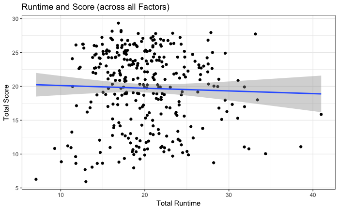

```
[1] -0.03526316
```

##### Relationship between graph score and drawing score

We might expect to see a positive, linear relationship between TM score and subsequent drawing score. How could students produce an accurate TM graph if they were not first able to answer questions with it?

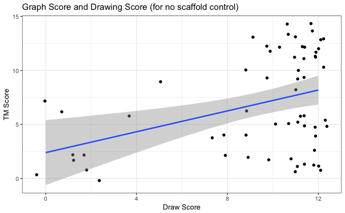

```
[1] 0.3856607
```

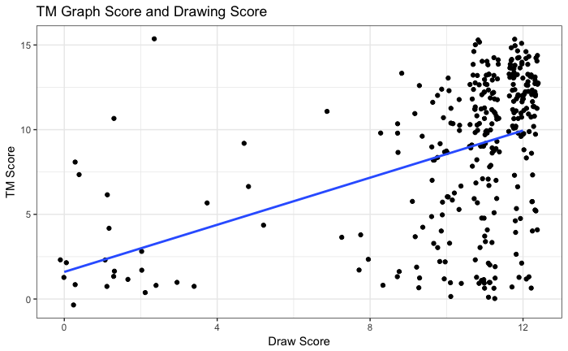

```
[1] 0.4369177
```

##### Relationship between graph score and drawing score by GRAPH INTERPRETATION

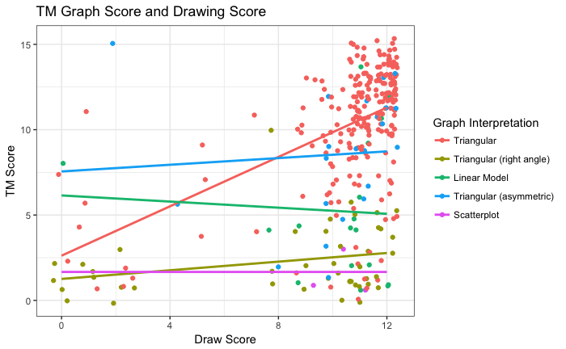

```
[1] 0.4369177
```

> What’s going on with the folks that score low on the TM model, and high on the drawing? What are their interpretations?

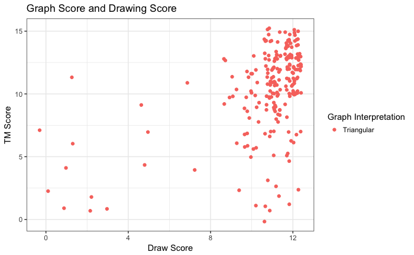

```
[1] 0.4369177
```

> DISPLAY TM INTERPRETATION

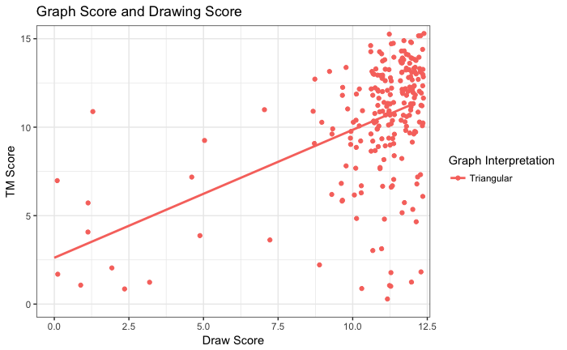

```
[1] 0.4732557
```

> DISPLAY RA INTERPRETATION

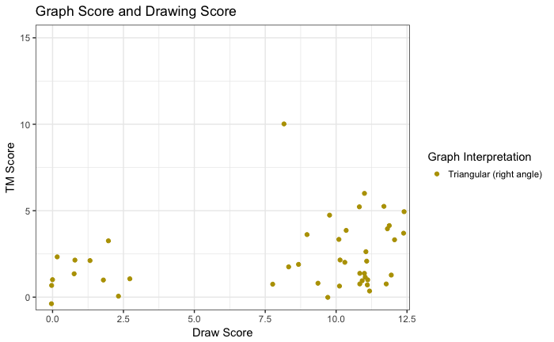

```
[1] 0.275282
```

> DISPLAY LM INTERPRETATION

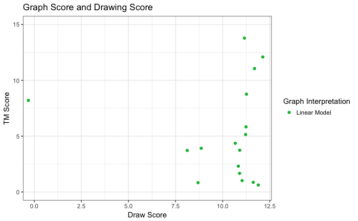

```
[1] -0.06156896
```

> DISPLAY ASY INTERPRETATION

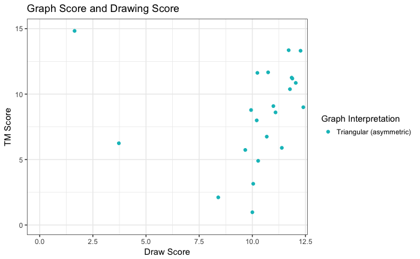

```
[1] 0.06697741
```

> DISPLAY SCATTERPLOT INTERPRETATION

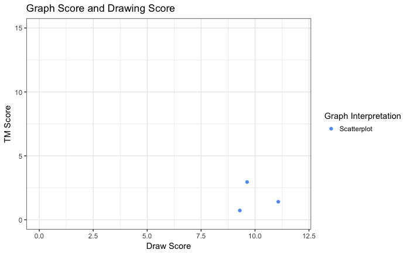

```
[1] 0
```

> DISPLAY ALL

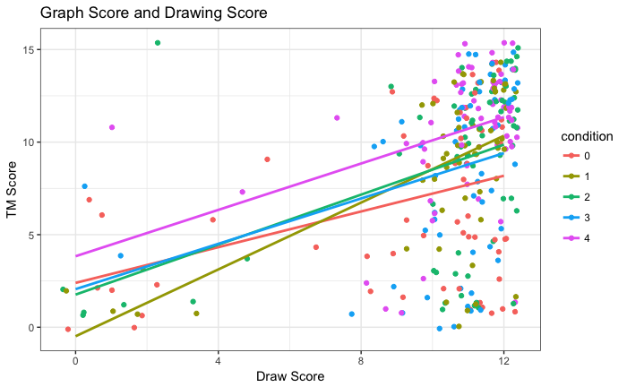

```
[1] 0.4369177
```

#### Are drawing time and score correlated?

No, they do not appear to be correlated

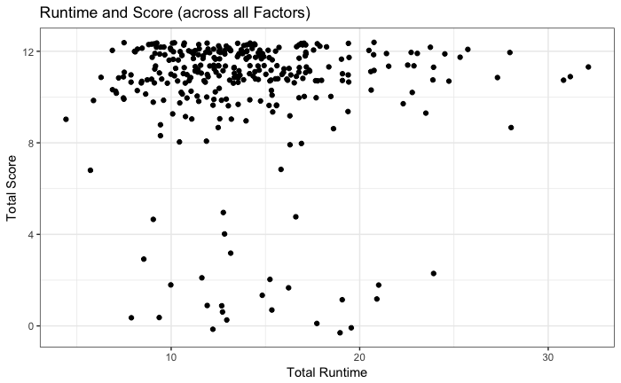

```
[1] -0.02337404
```

#### Assumptions: DO LM scores differ significantly by order or scaffold?

No, no significant difference are found in LM scores based on scaffold or task order. This confirms the assumption that LM is a conventional representation.

```
                 Df Sum Sq Mean Sq F value Pr(>F)
condition         4    1.3   0.336   0.073  0.990
order             1    2.3   2.322   0.501  0.480
condition:order   4    9.8   2.446   0.528  0.715
Residuals       306 1417.7   4.633
```

### MEANS TABLES

##### Mean Response time and Score for Graphing Tasks

| CONDITION | Score LM mean | Score LM sd | Score TM mean | Score TM sd | Time LM mean | Time LM sd | Time TM mean | Time TM sd |
| --- | --- | --- | --- | --- | --- | --- | --- | --- |
| 0 | 0.732 | 0.155 | 0.460 | 0.301 | 8.616 | 2.121 | 11.152 | 3.551 |
| 1 | 0.738 | 0.146 | 0.588 | 0.285 | 9.840 | 2.967 | 11.616 | 3.628 |
| 2 | 0.726 | 0.142 | 0.580 | 0.314 | 9.099 | 2.295 | 10.925 | 3.043 |
| 3 | 0.728 | 0.147 | 0.571 | 0.305 | 9.098 | 2.590 | 10.754 | 3.448 |
| 4 | 0.726 | 0.126 | 0.712 | 0.227 | 9.376 | 2.571 | 9.913 | 2.589 |
| All | 0.730 | 0.142 | 0.585 | 0.297 | 9.203 | 2.534 | 10.846 | 3.284 |

##### Mean Response time and Score for Drawing Tasks

| CONDITION | Score mean | Score sd | Time mean | Time sd |
| --- | --- | --- | --- | --- |
| 0 | 0.779 | 0.300 | 13.31 | 3.567 |
| 1 | 0.859 | 0.233 | 15.13 | 5.307 |
| 2 | 0.856 | 0.264 | 14.08 | 4.680 |
| 3 | 0.886 | 0.177 | 13.77 | 4.553 |
| 4 | 0.911 | 0.149 | 13.71 | 4.534 |
| All | 0.859 | 0.233 | 13.99 | 4.569 |

##### Mean TM Score by Drawing Interpretation

[output not shown]

| INTERPRETATION | Score All | Score mean | Score sd | Time mean | Time sd |
| --- | --- | --- | --- | --- | --- |
| Triangular | 230.00 | 10.39 | 3.43 | 10.603 | 3.092 |
| Triangular (right angle) | 44.00 | 2.30 | 1.98 | 12.192 | 4.063 |
| Linear Model | 17.00 | 5.24 | 4.16 | 11.228 | 3.680 |
| Triangular (asymmetric) | 22.00 | 8.55 | 3.73 | 10.617 | 2.782 |
| Scatterplot | 3.00 | 1.67 | 1.15 | 9.277 | 2.733 |
| All | 316.00 | 8.77 | 4.45 | 10.846 | 3.284 |

### SIMPLE: Compare Scaffolds to Control in TM SCORE

> Are scaffolds more effective than no scaffolds?

From the means, it appears that across all scaffold groups, scores were higher for scaffolds than the no-scaffold control. Students performed significantly better when they had access to a scaffold (M = 9.2, SD = 4.32) than when the did not (M = 6.9, SD = 4.51), t(88) = -3.64, p < .001, d = 0.53, a significant medium effect.

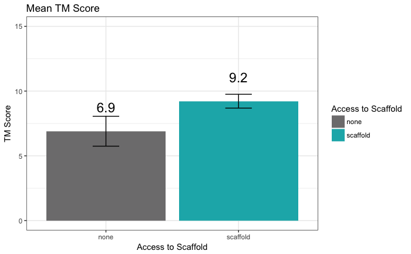

> Is this difference significant?

Students performed significantly better when they had access to a scaffold (M = 9.2, SD = 4.32) than when the did not (M = 6.9, SD = 4.51), t(88) = -3.64, p < .001, d = 0.53, a significant medium effect.

```
 Descriptive statistics by group
group: none
   vars  n mean   sd median trimmed  mad min max range skew kurtosis   se
X1    1 61  6.9 4.51      6    6.86 5.93   0  14    14 0.07    -1.47 0.58
------------------------------------------------------------------------------------------------------------------------------------------
group: scaffold
   vars   n mean   sd median trimmed  mad min max range  skew kurtosis   se
X1    1 255 9.22 4.33     10     9.6 4.45   0  15    15 -0.75    -0.68 0.27

    Welch Two Sample t-test

data:  triangular_score by scaffolded
t = -3.6352, df = 88.346, p-value = 0.0004662
alternative hypothesis: true difference in means is not equal to 0
95 percent confidence interval:
 -3.585093 -1.050844
sample estimates:
    mean in group none mean in group scaffold
              6.901639               9.219608


Cohen's d

d estimate: -0.5313728 (medium)
95 percent confidence interval:
       inf        sup
-0.8148757 -0.2478699
```

### Compare Scaffolds to Control in TM TIME

> Are scaffolds more effective than no scaffolds?

No signfificant differences in time

[figure not shown]

> Is this difference significant?

Students with access to scaffolds did not spend significantly more or less time on the TM task than those in the control group.

```
 Descriptive statistics by group
group: none
   vars  n  mean   sd median trimmed  mad  min   max range skew kurtosis   se
X1    1 61 11.15 3.55  11.42   11.11 2.89 3.14 19.31 16.17 0.04     -0.2 0.45
------------------------------------------------------------------------------------------------------------------------------------------
group: scaffold
   vars   n  mean   sd median trimmed  mad  min   max range skew kurtosis  se
X1    1 255 10.77 3.22  10.23   10.45 2.56 4.58 26.82 22.24 1.23     2.64 0.2

    Welch Two Sample t-test

data:  TM_T_M by scaffolded
t = 0.76123, df = 85.142, p-value = 0.4486
alternative hypothesis: true difference in means is not equal to 0
95 percent confidence interval:
 -0.610293  1.367547
sample estimates:
    mean in group none mean in group scaffold
              11.15180               10.77318


Cohen's d

d estimate: 0.1152316 (negligible)
95 percent confidence interval:
       inf        sup
-0.1653494  0.3958126
```

### Compare Scaffolds to Control in DIFF SCORE

> Are scaffolds more effective than no scaffolds?

If we account for the student’s performance on the LM graph by considering the difference in performance between the LM and TM graphs, we see that the difference in performance was significantly smaller when they had access to a scaffold (M = -1.73, SD = 3.88) than when the did not (M = -4.08, SD = 4.51), t(82) = -3.76, p < .001, d = 0.59, a significant medium effect.

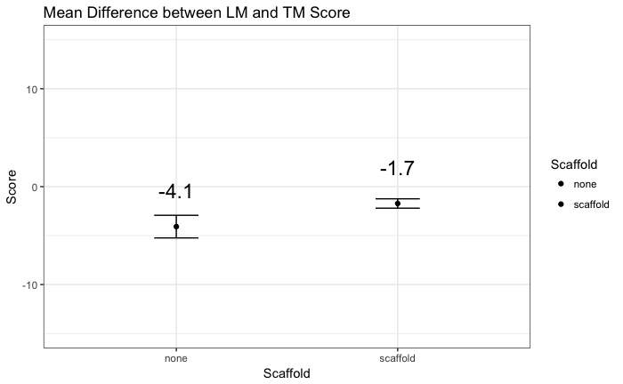

> Is this difference significant?

The difference in performance between the LM and TM graphs was significantly smaller when they had access to a scaffold (M = -1.73, SD = 3.88) than when the did not (M = -4.08, SD = 4.51), t(82) = -3.76, p < .001, d = 0.59, a significant medium effect.

```
 Descriptive statistics by group
group: none
   vars  n  mean   sd median trimmed  mad min max range skew kurtosis   se
X1    1 61 -4.08 4.51     -4   -4.12 5.93 -13   5    18 0.11    -1.04 0.58
------------------------------------------------------------------------------------------------------------------------------------------
group: scaffold
   vars   n  mean   sd median trimmed  mad min max range  skew kurtosis   se
X1    1 255 -1.72 3.88     -1    -1.4 2.97 -12   5    17 -0.71    -0.17 0.24

    Welch Two Sample t-test

data:  score_diff by scaffolded
t = -3.7671, df = 82.546, p-value = 0.0003087
alternative hypothesis: true difference in means is not equal to 0
95 percent confidence interval:
 -3.606762 -1.114035
sample estimates:
    mean in group none mean in group scaffold
             -4.081967              -1.721569


Cohen's d

d estimate: -0.588589 (medium)
95 percent confidence interval:
       inf        sup
-0.8727834 -0.3043947
```

### SIMPLE: TM Score by Scaffold Group

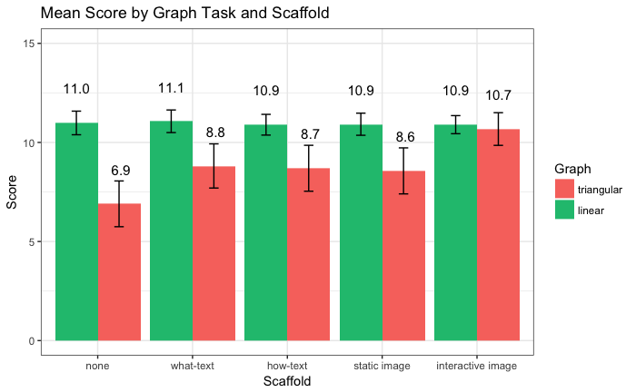

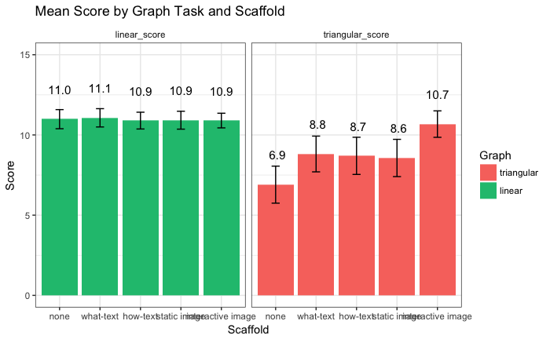

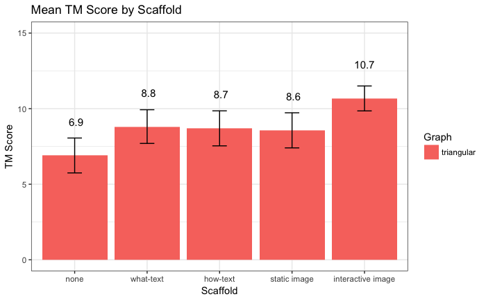

```
Call:
aov(formula = value ~ condition, data = t_scores)

Residuals:
   Min     1Q Median     3Q    Max
-9.677 -2.902  1.186  3.324  7.098

Coefficients:
            Estimate Std. Error t value Pr(>|t|)
(Intercept)  8.73063    0.24277  35.963  < 2e-16 ***
condition1  -1.82899    0.49156  -3.721 0.000236 ***
condition2   0.08293    0.49782   0.167 0.867806
condition3  -0.03366    0.47727  -0.071 0.943818
condition4  -0.16611    0.48855  -0.340 0.734075
---
Signif. codes:  0 ‘***’ 0.001 ‘**’ 0.01 ‘*’ 0.05 ‘.’ 0.1 ‘ ’ 1

Residual standard error: 4.31 on 311 degrees of freedom
Multiple R-squared:  0.07423,   Adjusted R-squared:  0.06232
F-statistic: 6.234 on 4 and 311 DF,  p-value: 7.754e-05

  Tukey multiple comparisons of means
    95% family-wise confidence level

Fit: aov(formula = value ~ condition, data = t_scores)

$condition
          diff         lwr      upr     p adj
1-0  1.9119200 -0.24736164 4.071202 0.1102152
2-0  1.7953304 -0.30493691 3.895598 0.1335241
3-0  1.6628768 -0.46968381 3.795437 0.2060796
4-0  3.7748312  1.68945189 5.860211 0.0000111
2-1 -0.1165896 -2.23527574 2.002096 0.9998828
3-1 -0.2490432 -2.39974610 1.901660 0.9977841
4-1  1.8629113 -0.24101728 3.966840 0.1102141
3-2 -0.1324536 -2.22390007 1.958993 0.9997950
4-2  1.9795009 -0.06381523 4.022817 0.0627214
4-3  2.1119545  0.03545911 4.188450 0.0440186
```

### DV: GRAPH SCORE

#### Construct a mixed ANOVA

```
Converting "subject" to factor for ANOVA.Data is unbalanced (unequal N per group). Make sure you specified a well-considered value for the type argument to ezANOVA().
```

|  | Effect | DFn | DFd | F | p | p<.05 | ges |
| --- | --- | --- | --- | --- | --- | --- | --- |
| 2 | condition | 4 | 296 | 4.24372694 | 2.351329e-03 | * | 3.740306e-02 |
| 3 | order | 1 | 296 | 0.73428345 | 3.921915e-01 |  | 1.677991e-03 |
| 4 | lm_scenarios | 1 | 296 | 22.25253533 | 3.689436e-06 | * | 4.846832e-02 |
| 9 | variable | 1 | 296 | 96.71109382 | 6.226124e-20 | * | 9.530930e-02 |
| 5 | condition:order | 4 | 296 | 0.68261709 | 6.044789e-01 |  | 6.211356e-03 |
| 6 | condition:lm_scenarios | 4 | 296 | 1.27789219 | 2.786863e-01 |  | 1.156531e-02 |
| 7 | order:lm_scenarios | 1 | 296 | 0.04326807 | 8.353644e-01 |  | 9.903297e-05 |
| 10 | condition:variable | 4 | 296 | 10.03978618 | 1.241419e-07 | * | 4.191296e-02 |
| 11 | order:variable | 1 | 296 | 3.42950549 | 6.503691e-02 |  | 3.721953e-03 |
| 12 | lm_scenarios:variable | 1 | 296 | 34.34297121 | 1.230461e-08 | * | 3.606168e-02 |

[output cut: 5 more lines]

```
      Length Class      Mode
ANOVA 7      data.frame list
```

[output not shown]

#### Main Effect: GRAPH

LM Model scores were significantly higher than TM scores.

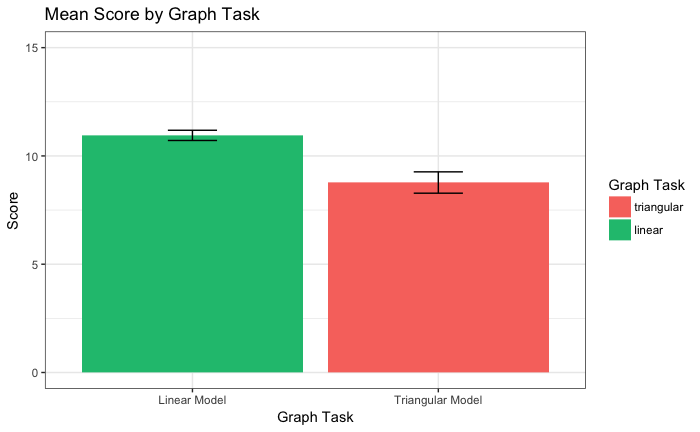

#### Main Effect of SCAFFOLD

Only condition #4: interactive graph, yielded significantly better performance than the control

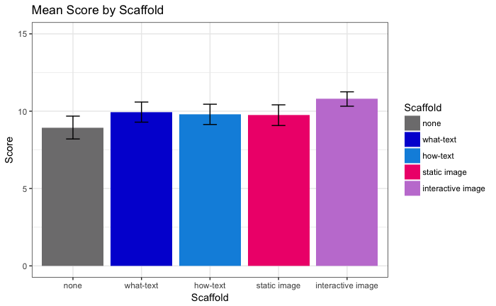

#### Main Effect of SCENARIO

Scores were significantly lower in the axis scenario than the longmire scenario.

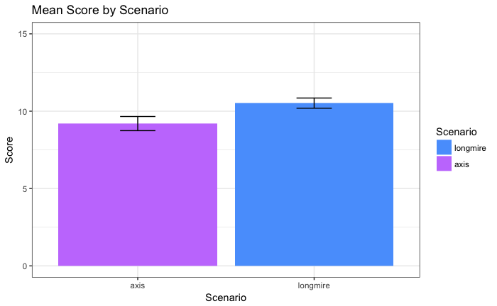

#### Interaction of GRAPH & SCAFFOLD

There was a significant interaction between graph-type and the scaffold condition,

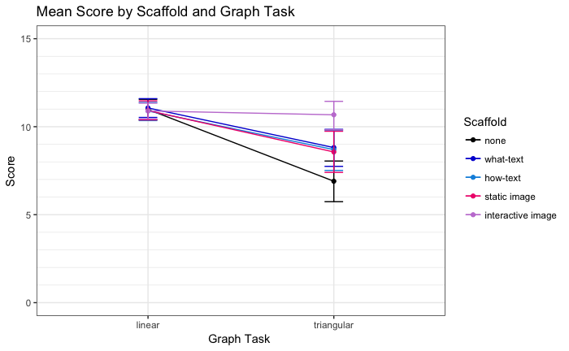

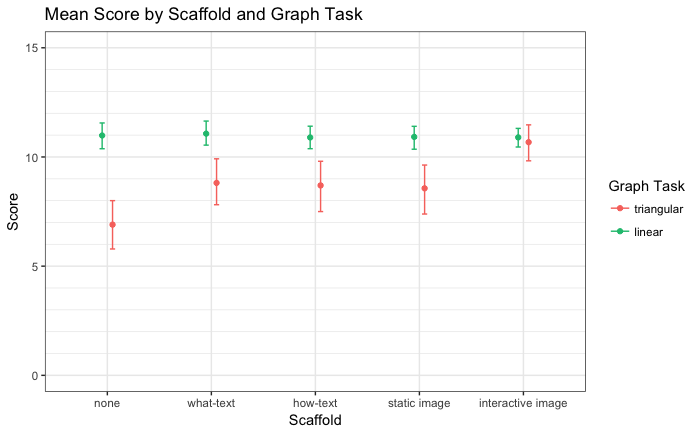

#### Interaction of GRAPH & SCENARIO

There was a significant interaction between graph-type and scenario

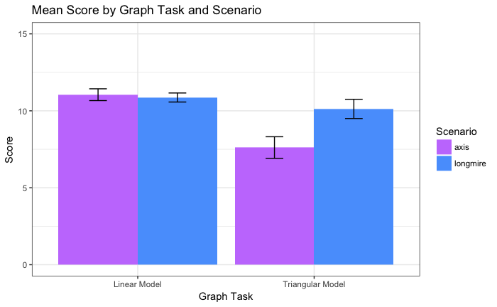

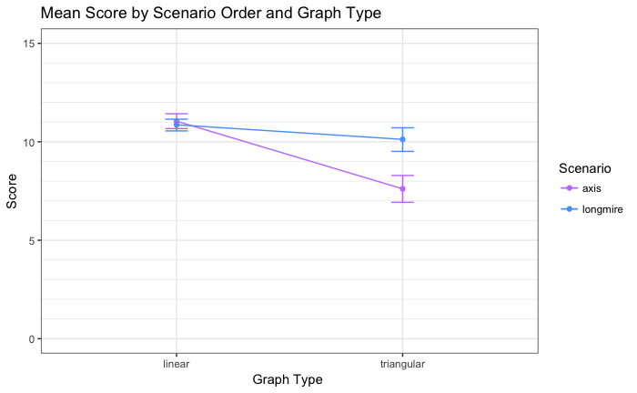

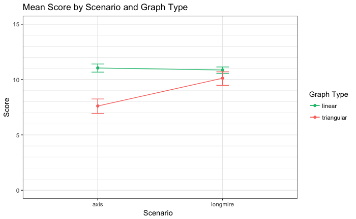

#### (almost) Interaction of GRAPH & ORDER

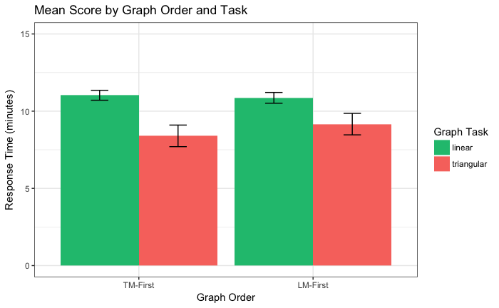

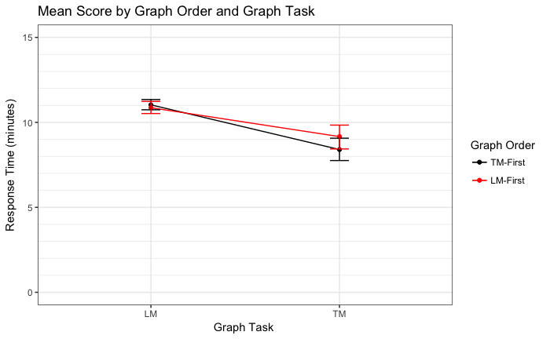

[figure not shown]

#### Interaction of GRAPH & SCAFFOLD & ORDER

The three-way interaction of graph-type, scaffold condition and graph-order approached significance at F(4,297) = 2.03, p = 0.09

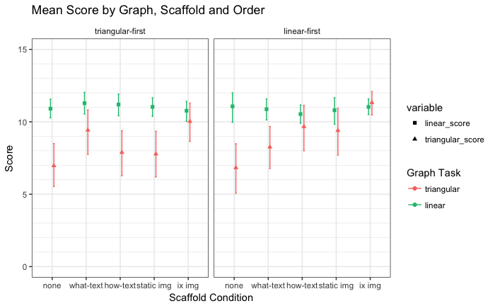

[figure not shown]

[figure not shown]